# Ruby @ Elementi di Bioinformatica

Raoul J.P. Bonnal: r@bioruby.org

4 Ottobre 2013

# Ruby

# le origini e la storia

E' stato rilasciato ufficialmente nel 1995 e solo nel 2006 la base di utenza ha raggiunto una diffusione tale da considerarlo non piu un linguaggio di nicchia.

Il suo creatore è Yukihiro (*Matz*) Matsumoto

> Trying to make Ruby natural, not simple.

> Ruby is simple in appearance, but is very complex inside, just like our human body

# Diverse Implementazioni

- [MRI](https://www.ruby-lang.org/en/) Matz's Ruby Interpreter. L'implementazione in C aggiornata con le ultimissime novità discusse nelle [mailing list](https://www.ruby-lang.org/en/community/mailing-lists/)
- [JRuby](http://jruby.org/) E' l'implementazione in Java, non è aggiornata alle ultime specifiche ufficiali del linguaggio. Generalmente è in ritardo di una release. Con il tempo risulta essere stabile e sfrutta in modo eccellente le migliorie delle nuove JVM. Sta acquisendo sempre più seguito e credito perchè permette l'integrazione di codice Java preesistente con nuove estensioni in Ruby.

# Diverse Implementazioni

- [Ruboto](http://ruboto.org/) è un framework per lo sviluppo di applicazioni native Android, utilizzando JRuby.
- [Rubinius](http://rubini.us/) Implementazione in C++ ma lo sviluppo non è allineato con le specifiche del linguaggio.
- [Ree](http://www.rubyenterpriseedition.com/) E' una versione orientata al mondo server che include significative migliorie in termini di prestazioni e gestione della memoria. Assolutamente da usare quano le risorse hardware risultano limitate oppure costano molto.

# Perché lo scripting ?

Una metodologia agile che privilegia la velocità di sviluppo per ottenere risultati nel più breve tempo possibile.

# Perché lo scripting ?

Una metodologia agile che privilegia la velocità di sviluppo per ottenere risultati nel più breve tempo possibile.

Conseguenze:

# Perché lo scripting ?

Una metodologia agile che privilegia la velocità di sviluppo per ottenere risultati nel più breve tempo possibile.

Conseguenze:

- necessità continua di refactoring e implementazione di nuove specifiche

# Perché lo scripting ?

Una metodologia agile che privilegia la velocità di sviluppo per ottenere risultati nel più breve tempo possibile.

Conseguenze:

- necessità continua di refactoring e implementazione di nuove specifiche
- ciclo di vita del software molto breve

# MA

- il software perfetto non esiste
- le specifiche le definiamo noi
- meglio qualcosa che niente

# Ruby e la Bioinformatica

- BioRuby: E' una libreria specifica per la BioInformatica che permette la manipolazione e gestione di diversi oggetti *biologici*
- SciRuby: Algebra, Matrici, Statistica
- Google Summer of Code *is a global program that offers students stipends to write code for open source projects.*

# Installazione

GNU/Linux - OSX

- [from scratch](https://www.ruby-lang.org/en/downloads/)
- [RVM](https://rvm.io/) Ruby Version Manager
- rbenv

Windows

- [Ruby Installer](http://rubyinstaller.org/)

# Installazione

### RVM

```
\curl -L https://get.rvm.io | bash -s stable

rvm install 2.0.0

# some very simple configuration for your .bash_profile .profile .bashrc

rvm use 2.0.0

rvm list

# jruby-1.7.4 [ x86_64 ]
# ruby-1.9.3-p448 [ x86_64 ]
# =* ruby-2.0.0-p247 [ x86_64 ]
```

# Come interagire con Ruby

- IRB Interactive Ruby Shell
- [Pry](http://pryrepl.org/)
  - syntax highlighting
  - flexible plugin architecture
  - runtime invocation
  - source and documentation browsing
  - posso interagire anche con la shell direttamente

# Pry

```
pry(main)> cd FileUtils
pry(FileUtils):1> show-method rm

From: /opt/ruby/lib/ruby/1.9.1/fileutils.rb @ line 556:
Number of lines: 10
Owner: FileUtils

def rm(list, options = {})
  fu_check_options options, OPT_TABLE['rm']
  list = fu_list(list)
  fu_output_message "rm#{options[:force] ? ' -f' : ''} #{list.join ' '}" if options[:verbose]
  return if options[:noop]

  list.each do |path|
    remove_file path, options[:force]
  end
end
pry(FileUtils):2>
```

# Il linguaggio

# Stringhe

### Creazione

```
bio_text_format = "In bioinformatica\nle informazioni vengono il più delle volte salvate e scambiate in file di testo."
puts bio_text_format
# => In bioinformatica
# => le informazioni vengono il più delle volte salvate e scambiate in file di testo.

bio_text_unformat = 'In bioinformatica\nle informazioni vengono il più delle volte salvate e scambiate in file di testo.'
puts bio_text_unformat
# => In bioinformatica\nle informazioni vengono il più delle volte salvate e scambiate in file di testo.
```

# Stringhe

### Creazione multi linee

```
bio_text_format = <<-STR
La bioinformatica è una disciplina scientifica dedicata alla risoluzione di problemi biologici a livello molecolare con metodi informatici.
Essa costituisce un tentativo di descrivere dal punto di vista numerico e statistico i fenomeni biologici: storicamente ed epistemologicamente la biologia ha fatto minor ricorso ad un approccio matematico rispetto ad altre discipline scientifiche (quali fisica e chimica). La bioinformatica quindi tenta di supplire a questa lacuna fornendo ai risultati tipici della biochimica e della biologia molecolare un corredo di strumenti analitici e numerici. Vengono coinvolte, oltre all'informatica, matematica applicata, statistica, chimica, biochimica e nozioni di intelligenza artificiale.
STR
```

# Stringhe

### Semplici operazioni

```
bio_text_format = "In bioinformatica\nle informazioni vengono il più delle volte salvate e scambiate in file di testo."
bio_text_format.size #length
# => 98

bio_text_format.count 'a'
# => 7
```

# Stringhe

### Comparazione

```
"In bioinformatica\nle informazioni vengono il più delle volte salvate e scambiate in file di testo." == 'In bioinformatica\nle informazioni vengono il più delle volte salvate e scambiate in file di testo.'
# => false

"In bioinformatica\\nle informazioni vengono il più delle volte salvate e scambiate in file di testo." == 'In bioinformatica\nle informazioni vengono il più delle volte salvate e scambiate in file di testo.'
# => true
```

# Stringhe

### Manipolazione

Da minuscolo a maiuscolo e ancora minuscolo

[output not shown]

# Stringhe

### Manipolazione

Puliamo la stringa da spazi e a capo in testa e in coda

```
bio_text_format = "\t\t\nIn bioinformatica\nle informazioni vengono il più delle volte salvate e scambiate in file di testo.\n\n\n\n\t\t  \n"
bio_text_format.strip
# => "In bioinformatica\nle informazioni vengono il più delle volte salvate e scambiate in file di testo."
```

# Stringhe

### Manipolazione

Rimuoviamo dal testo il carattere *a*

[output not shown]

# Stringhe

### Manipolazione

Cambiamo a mano il *newline*

```
bio_text_format = "In bioinformatica\nle informazioni vengono il più delle volte salvate e scambiate in file di testo."
bio_text_format[17] = ' '
# => " "

bio_text_format
# => "In bioinformatica le informazioni vengono il più delle volte salvate e scambiate in file di testo."
```

# Stringhe

### Manipolazione

Estrazione di una sotto stringa

```
bio_text_format = "In bioinformatica\nle informazioni vengono il più delle volte salvate e scambiate in file di testo."
bio_text_format[18..33]
# => "le informazioni "
```

# Stringhe

### Impediamo la Manipolazione

Cambiamo a mano il *newline*

```
bio_text_format = "In bioinformatica\nle informazioni vengono il più delle volte salvate e scambiate in file di testo."
bio_text_format.freeze
bio_text_format[17] = ' '
# RuntimeError: can't modify frozen String
```

# Stringhe

### Manipolazione e Pattern Matching

Per poter sostituire parti di una stringa

```
bio_text_format = "In bioinformatica\nle informazioni vengono il più delle volte salvate e scambiate in file di testo."
bio_text_format.gsub(/le informazioni/,'i dati').gsub(/ate/,'ati')
# => "In bioinformatica\ni dati vengono il più delle volte salvati e scambiati in file di testo."
```

# Stringhe

### Pattern Matching

```
bio_text_format = "In bioinformatica\nle informazioni vengono il più delle volte salvate e scambiate in file di testo."
bio_text_format =~ /informazioni/
# => 21

$` # la parte di stringa prima del match
# => "In bioinformatica\nle "

$& # ciò che l'espressione regolare ha verificato
# => "informazioni"

$' # la parte di stringa dopo il match
# => " vengono il più delle volte salvate e scambiate in file di testo."
```

# Stringhe

### Pattern Matching

```
bio_text_format = "In bioinformatica\nle informazioni vengono il più delle volte salvate e scambiate in file di testo."
bio_text_format =~ /informazioni/
# => 21

$` # la parte di stringa prima del match
# => "In bioinformatica\nle "

$& # ciò che l'espressione regolare ha verificato
# => "informazioni"

$' # la parte di stringa dopo il match
# => " vengono il più delle volte salvate e scambiate in file di testo."
```

Spesso questo tipo di *pattern matching* viene utilizzato per verificare delle condizioni e operare delle scelte in funzione dell' input.

# Stringhe

### Pattern Matching e If statement

Vogliamo sapere il # di GC nella sequenza ma solo se la stringa ha DNA come prefisso

```
sequence = 'DNA:acgtaggaccgacagcagatgcccgagatggacg'

if sequence =~ /DNA/
  puts sequence.count 'gc' #conta i singoli caratteri non la coppia
else
  puts 'Non è DNA, non ha senso contato il conenuto di GC'
end

# => 21
```

# Stringhe

### Pattern Matching e If statement

Vogliamo sapere il # di GC nella sequenza ma solo se la stringa ha DNA come prefisso ma in questo caso non ci serve una stringa di ritorno ma il numero che andremo a salvare in una variabile

```
sequence = 'DNA:acgtaggaccgacagcagatgcccgagatggacg'

if sequence =~ /DNA/
  gc = sequence.count 'gc' #conta i singoli caratteri non la coppia
else
  gc = 0
end

puts gc

# => 21
```

# Stringhe

### Pattern Matching e If statement

Vogliamo sapere il # di GC nella sequenza ma solo se la stringa ha DNA come prefisso ma in questo caso non ci serve una stringa di ritorno ma il numero che andremo a salvare in una variabile

```
sequence = 'DNA:acgtaggaccgacagcagatgcccgagatggacg'

gc = if sequence =~ /DNA/
  sequence.count 'gc' #conta i singoli caratteri non la coppia
else
  0
end

puts gc

# => 21
```

# Stringhe

### Pattern Matching e If statement

Vogliamo sapere il # di GC nella sequenza ma solo se la stringa ha DNA come prefisso ma in questo caso non ci serve una stringa di ritorno ma il numero che andremo a salvare in una variabile

```
sequence = 'DNA:acgtaggaccgacagcagatgcccgagatggacg'

gc = sequence =~ /DNA/ ? sequence.count('gc') : 0

puts gc





# => 21
```

# Stringhe

### Pattern Matching e If statement

Vogliamo sapere il # di GC nella sequenza ma solo se la stringa ha DNA come prefisso ma in questo caso non ci serve una stringa di ritorno ma il numero che andremo a salvare in una variabile

```
sequence = 'DNA:acgtaggaccgacagcagatgcccgagatggacg'

gc = sequence.count('gc') if sequence =~ /DNA/

puts gc

# => 21
```

In questo ultimo caso non ci interessa assegnare un valore a *gc* nel caso non sia DNA perchè probabilmente non ce ne faremmo nulla o comunque controlleremmo prima di usarlo.

# Stringhe

### Pattern Matching e If statement

Vogliamo sapere il # di GC nella sequenza ma solo se la stringa ha DNA come prefisso ma in questo caso non ci serve una stringa di ritorno ma il numero che andremo a salvare in una variabile

```
sequence = 'RNA:acgtaggaccgacagcagatgcccgagatggacg'

gc = sequence.count('gc') if sequence =~ /DNA/

if gc
  puts "Il contenuto di GC nella sequenza di DNA è #{gc}"
end
```

non otterremo nulla perchè a *gc* viene attribuito il valore *nil* in automatico

# Tutto è un oggetto

# Un ID univoco

Ogni oggetto in Ruby è identificato da una chiave univoca che corrisponde all'ID dell'oggetto

```
bio_text_format = "In bioinformatica\nle informazioni vengono il più delle volte salvate e scambiate in file di testo."
# => 70347711225800
object = ObjectSpace._id2ref(70347711225800) # questo è come e fosse un puntatore all'oggetto bio_text_format
object == bio_text_format
# => true
alt_string = "In bioinformatica\nle informazioni vengono il più delle volte salvate e scambiate in file di testo."
bio_text_format == alt_string
# => true
bio_text_format.equal? alt_string
# => false
alt_string.object_id
# => 70347702565640
```

# Tutto è un oggetto

Ecco come Ruby valuta/considera cosa noi gli diamo in input

```
[65] pry(main)> [nil, "1", :uno, 1, 3.5, YAML, Class, Module  ].each{|x| puts "#{x.is_a? Object} #{x.is_a? Module} #{x.class} #{x.class.superclass}"}

--------------------------------------------------
| Object | Module | Class Type | Main Class Type |
--------------------------------------------------
|  true  | false  |  NilClass  |    Object       |
|  true  | false  |  String    |    Object       |
|  true  | false  |  Symbol    |    Object       |
|  true  | false  |  Fixnum    |    Integer      |
|  true  | false  |  Float     |    Numeric      |
|  true  | true   |  Module    |    Object       |
|  true  | true   |  Class     |    Module       |
|  true  | true   |  Class     |    Module       |
--------------------------------------------------
```

# Tutto è vero

# Tranne *nil* e *false*

# Tranne *nil* e *false*

Perchè prima non ho ritornato il valore ZERO ?

```
sequence = 'RNA:acgtaggaccgacagcagatgcccgagatggacg'

gc = sequence.count('gc') if sequence =~ /DNA/

if gc
  puts "Il contenuto di GC nella sequenza di DNA è #{gc}"
end
```

# Tranne *nil* e *false*

Perchè prima non ho ritornato il valore ZERO ?

```
sequence = 'RNA:acgtaggaccgacagcagatgcccgagatggacg'

gc = sequence.count('gc') if sequence =~ /DNA/

unless gc.nil? # if !gc.nil?
  puts "Il contenuto di GC nella sequenza di DNA è #{gc}"
end
```

Perchè in Ruby è sufficiente che un oggetto sia diverso da *nil* o da *false* perchè l'espressione in cui viene valutato risulti vera.

# Tranne *nil* e *false*

Perchè prima non ho ritornato il valore ZERO ?

```
sequence = 'RNA:acgtaggaccgacagcagatgcccgagatggacg'

gc = sequence.count('gc') if sequence =~ /DNA/


puts "Il contenuto di GC nella sequenza di DNA è #{gc}" unless gc.nil? # if !gc.nil?
```

Perchè in Ruby è sufficiente che un oggetto sia diverso da *nil* o da *false* perchè l'espressione in cui viene valutato risulti vera.

# Tranne *nil* e *false*

Perchè prima non ho ritornato il valore ZERO ?

```
sequence = 'RNA:acgtaggaccgacagcagatgcccgagatggacg'

gc = sequence.count('gc') if sequence =~ /DNA/


gc && puts("Il contenuto di GC nella sequenza di DNA è #{gc}")
```

Perchè in Ruby è sufficiente che un oggetto sia diverso da *nil* o da *false* perchè l'espressione in cui viene valutato risulti vera.

# Assegnamenti

Vogliamo scrivere uno script che ci permetta di avere un parametro di default nel caso l'utente non ci passi il nome del file in cui andremo a scrivere il nostro output.

Perchè non usare le espressioni booleane a nostro vantaggio ?

# Assegnamenti

Vogliamo scrivere uno script che ci permetta di avere un parametro di default nel caso l'utente non ci passi il nome del file in cui andremo a scrivere il nostro output

```
file_name = ARGV[0] || "data-output.txt"  #Short-Circuit Evaluation
# mi serve assolutamente un nome di file

file_name ||= ARGV[0]
# il nome è opzionale e viene assegnato solo se l'utente lo passa. Risulta ovvio che prima di utilizzare file_name per scrivere sul file devo verificare che il valore sia presente.
```

# Assegnamenti

Sono anche possibili assegnamenti multipli

```
nome, cognome, eta, sesso = 'John', 'Doe', 35, 'Male'
# => ["John", "Doe", 35, "Male"]
```

# Assegnamenti

*swap* in una unica istruzione

```
min = 100
max = 35
min, max = max, min if max < min
# => [35, 100]
```

# Numeri

[output not shown]

# Numeri

```
10    # i numeri decimali sono preceduti da 0d che però può essere omesso
# => 10
010   # i numeri ottali sono preceduti da uno 0
# => 8
0x10  # i numeri esadecimali sono preceduti da 0x
# => 16
0b10  # i numeri binari sono preceduti da 0b
# => 2
```

# Numeri

E' possibile convertire numeri in stringhe e stringhe in numeri

```
10.to_s
# => "10"
"23".to_i
23
```

# Numeri

### Operazioni aritmetiche

- +
- `-` binario ( x - y )
- / divisione per interi se non specificato
- % modulo
- ** elevazione a potenza
- `-` cambio di segno (-x)

# Array

Gli array possono contentere tipi di dati eterogenei

```
ary = [ 10, 'Dieci', :dieci, 55.33]

puts ary[0]
# => 10

puts ary[-1]
# => 55.33
```

# Array

nel caso di array di stringhe questi possono essere creati usando una sintassi particolare

```
ary = %w( uomo cane gatto pesce oca)

puts ary[0]
# => uomo

puts ary[-1]
# => oca
```

# Array

### Operazioni

```
ary_one = %w( uomo cane gatto pesce oca)
ary_two = [ 10, 'Dieci', :dieci, 55.33, 'pesce']

ary_union = (ary_one + ary_two)
# => ["uomo", "cane", "gatto", "pesce", "oca", 10, "Dieci", :dieci, 55.33, "pesce"]

ary_union = (ary_one + ary_two).uniq
# => ["uomo", "cane", "gatto", "pesce", "oca", 10, "Dieci", :dieci, 55.33]

ary_union.sort
# => ArgumentError: comparison of String with 10 failed
```

Per alcune operazioni non è possibile operare su tipi di dato che non siano compatibili.

# Hash

Ruby li utilizza largamente:

- strutture dati come Struct, OpenStruct sono Hash con steroidi
- il passaggio di parametri opzionali ai metodi è basato su hash
- veloci db/dizionari in memoria

# Hash

```
hash = { 'dna' =>'acido desossiribonucleico',
         'rna' => 'acido ribonucleico'
       }
```

le chiavi di un hash possono essere di diversi tipi. Generalmente quando si vogliono utilizzare delle *stringhe* come chiavi è meglio utilizzare i *simboli*

# Hash

### Simboli

```
hash = { :dna =>'acido desossiribonucleico',
         :rna => 'acido ribonucleico'
       }
```

Nel caso degli Hash i simboli sono usati moltissimo. I simboli sono da considerarsi come delle etichette il cui nome ha un significato, di per se non contengono nessun valore. Non sono da confondere con le stringhe, infatti sono un tipo a parte.

```
dna = :dna
rna = :rna
dna.class
# => Symbol
dna_x = :dna
dna.object_id
# => 1387528
dna_x.object_id
# => 1387528
```

# Iteratori

Ruby ci permette di iterare su molti tipi di dati: Stringhe, Array, Hash e il più delle volte non dobbiamo nemmeno più utilizzare quei *brutti* costrutti quali *while*, *for*, *loop*, ... Invece possiamo in modo elegante utilizzare la parola magica **each**

# Iteratori

Scorrere il contenuto di un array e recuperare il tipo di dato

```
ary = [ 10, 'Dieci', :dieci, 55.33, 'pesce']
ary.each do |item|
  puts item.class
end
# Fixnum
# String
# Symbol
# Float
# String
```

# Iteratori

```
dict = Hash.new(0)
sequence = 'acgtaggaccgacagcagatgcccgagatggacg'
sequence.each_char do |car|
  dict[car]+=1
end
# => {"a"=>10, "c"=>9, "g"=>12, "t"=>3}
```

# Iteratori

```
dict = Hash.new(0)
sequence = 'acgtaggaccgacagcagatgcccgagatggacg'
sequence.each_char do |car|
  dict[car]+=1
end
# => {"a"=>10, "c"=>9, "g"=>12, "t"=>3}

puts dict.keys
# a
# c
# g
# t
```

# Iteratori

```
dict = Hash.new(0)
sequence = 'acgtaggaccgacagcagatgcccgagatggacg'
sequence.each_char do |car|
  dict[car]+=1
end
# => {"a"=>10, "c"=>9, "g"=>12, "t"=>3}

dict.each_pair do |car, n|
  #allineiamo i numeri a destra
  printf "%s -> %2d\n", car, n
end
# a -> 10
# c ->  9
# g -> 12
# t ->  3
```

# Iteratori

Creiamo una sequenza tandem

```
seq = 'acgtag'
n = 5
tandem = ''
n.times { tandem+= seq}
```

# Iteratori

Creiamo una sequenza tandem

```
seq = 'acgtag'
n = 5
tandem = ''
n.times { |i| tandem+= seq; puts "#{i}: #{tandem}"}

# 0: acgtag
# 1: acgtagacgtag
# 2: acgtagacgtagacgtag
# 3: acgtagacgtagacgtagacgtag
# 4: acgtagacgtagacgtagacgtagacgtag
```

# Blocchi

Gli iteratori sono **cool** ma da soli non bastano!

# Blocchi

Gli iteratori sono **cool** ma da soli non bastano!

Abbiamo bisogno dei **BLOCCHI**

# Blocchi

Gli iteratori sono **cool** ma da soli non bastano!

Abbiamo bisogno dei **BLOCCHI**

```
3.times{ puts "BLOCK ROCKS!" }
```

# Blocchi

Gli iteratori sono **cool** ma da soli non bastano!

Abbiamo bisogno dei **BLOCCHI**

```
3.times{ puts "BLOCK ROCKS!" }
```

Intuitivamente il *blocco* è una porzione di codice che può essere passata a un metodo che successivamente lo esegue.

Iteratore

```
3.times
```

Blocco

```
{ puts "BLOCK ROCKS!" }
```

# Blocchi

```
3.times { puts "BLOCK ROCKS!" }
```

**=**

```
3.times do
  #just add a line to use a multi line block
  puts "BLOCK ROCKS!"
end
```

# Blocchi

Possiamo anche stampare il numero di iterazione

# Blocchi

Possiamo anche stampare il numero di iterazione

```
3.times do |index|
  puts "#{index} BLOCK ROCKS!"
end

# 0 BLOCK ROCKS!
# 1 BLOCK ROCKS!
# 2 BLOCK ROCKS!
```

# Blocchi

Possiamo costruire un metodo che accetta un blocco di codice e lo esegue

```
def crunch
  puts "All' interno di crunch"
  yield
end

crunch { puts 'esegue il mio blocco'}

# All' interno di crunch
# esegue il mio blocco
```

# Blocchi

Possiamo costruire un metodo che accetta un blocco di codice e lo esegue

```
def crunch(name)
  puts "All' interno di crunch"
  puts name
  yield
end

crunch('Ruby') { puts 'esegue il mio blocco'}

# All' interno di crunch
# Ruby
# esegue il mio blocco
```

# Blocchi

Possiamo anche passare un parametro direttamente al blocco

```
def crunch(name)
  puts "All' interno di crunch"
  yield name
end

crunch('Ruby') do |name|
  puts "#{name.upcase} esegue il mio blocco"
end

# All' interno di crunch
# RUBY esegue il mio blocco
```

# Blocchi

Possiamo anche passare più di un parametro direttamente al blocco

```
def crunch(name)
  std_message = "All' interno di crunch"
  yield std_message, name
end

crunch('Ruby') do |message, name|
  puts "#{message} #{name.upcase} esegue il mio blocco"
end

# All' interno di crunch RUBY esegue il mio blocco
```

# Blocchi

I blocchi possono essere anche opzionali all'interno di un metodo. Abbiamo quindi un comportamento di *default* e uno *particolare* nel caso di un blocco

```
def crunch(name)
  std_message = "All' interno di crunch"
  if block_given?
    yield std_message, name
  else
    puts "#{std_message} non ho nulla da fare -_-'"
  end
end

crunch('Ruby')
# All' interno di crunch non ho nulla da fare -_-'

crunch('Ruby'){|message, name| puts "#{message} #{name} deve ancora fare molto lavoro." }
# All' interno di crunch Ruby deve ancora fare molto lavoro.
```

# Proc - Lambda

```
block = Proc.new {|first, second| puts "My firsy name is #{first} and the last name is #{second}"}
# => #<Proc:0x007fee1328cec8@(pry):61>

block.call('John', 'Doe', 'Unkown')
# My firsy name is John and the last name is Doe

lambda_block = lambda {|first, second| puts "My firsy name is #{first} and the last name is #{second}"}
# => #<Proc:0x007fee133952c0@(pry):63 (lambda)>

lambda_block.call('John', 'Doe', 'Unkown')
# ArgumentError: wrong number of arguments (3 for 2)
```

Esistono due differenze sostanziali tra Proc e funzioni Lambda:

- la funzione Lambda effettua il controllo sull'arietà dei parametri mentre Proc no
- quando inserita in un metodo il return presente in una Proc ritorna subito (termina l'esecuzione del metodo in cui è chiamata)

# I/O

Un esempio di utilizzo dei blocci è tramite l'accesso ai file. Supponiamo che vogliamo fare una copia di un file.

```
File.open("dna_sequence.fasta",'r') do |rfile|
  File.open("dna_sequence.fasta.backup",'w') do |wfile|
    rfile.each_line do |rline|
      wfile.write(rline)
    end
  end
end #si preoccupa di chiudere l'handler in letture
```

# I/O

Ci sono diversi iteratori per la lettura di un file

```
file.each_byte

file.each_char

file.each_line

file.readline

file.readlines #carica tutto il file in memoria creando un array di array
```

# Da Procedurale a OO

Creiamo una sequenza tandem ma cerchiamo di farlo in modo semplice

[output not shown]

Alcune operazioni aritmentiche possono quindi essere applicate a differenti tipi di dati e il comportamento è specifico di quel tipo.

# Classi

Potremmo anche creare un metodo che genera un tandem a partire da una stringa

```
# La sequenza tandem di una stringa è la stringa ripetuta
# n volte
def tandem(seq, n=1)
  seq * n
end
```

ma dato che non c'è controllo sui tipi dei parametri nel caso

```
seq = nil
```

otterremo un

```
NoMethodError: undefined method `*' for nil:NilClass
```

# Classi

Potremmo quindi modificare il metodo

```
def tandem(seq, n)
  seq * n unless seq.nil?
end
```

Non vi pare poco chiara questa sintassi (*cumbersome*) ?

Una soluzione potrebbe essere quella di estendere la classe **String*** e aggiungere il metodo **tandem**

# Classi

### Estendiamo String

```
class String
  def tandem(n=1)
    self * n
  end
end
```

# Classi

### Estendiamo String

```
class String
  def tandem(n=1)
    self * n
  end
end
```

- passaggio dei parametri a default
- *self* che è la referenza all'oggetto istanziato su cui viene chiamato il metodo

# Classi

### Estendiamo String

```
class String
  def tandem(n=1)
    self * n
  end
end
```

Tuttavia non ha molto senso che tutte le stringe possano generare dei *tandem* dato che per noi riveste un significato solo nel contesto biologico.

# Classi

### una classe BioString

estendendola con il nostro metodo *tandem*

```
class BioString < String
  def tandem(n=1)
    self * n
  end
end

string = "agcgatgca"
string.tandem 10
# => NoMethodError: undefined method `tandem' for "agcgatgca":String

sequence = BioString.new "agcgatgca"
tandem = sequence.tandem 2
sequence.object_id
# => 70341335399180
tandem.object_id
# => 70341347607400
```

# Classi

### una classe BioString

ma vorremmo anche avere un metodo che mi permetta di modificare in modo permanente la mia stringa

```
class BioString < String
  def tandem!(n=1)
    self << self * (n-1)
  end
end

sequence = BioString.new "agcgatgca"
tandem = sequence.tandem! 2
sequence.object_id
# => 70341335399180
tandem.object_id
# => 70341335399180
```

*sequence* e *tandem* puntano allo stesso oggetto perchè bisogna sapere che in Ruby il valore ritornato da un metodo è sempre l'ultima espressione valutata dal metodo che è stato chiamato.

# Classi

Aggiungiamo degli attributi

```
class BioString < String
  attr_accessor :name
end

bs = BioString.new "acgtaggacgcagt"
bs.name
# => nil

bs.name = "DNA:unkown"
bs.name
# => DNA:unkown
```

# Classi

Aggiungiamo degli attributi e variabili di istanza

```
class BioString < String
  attr_accessor :name

  def initialize(str=nil)
    super(str)
    @quality = :unkown
  end
end

bs = BioString.new "acgtaggacgcagt"
bs.quality
# => NoMethodError: undefined method `quality' for "acgtaggacgcagt":BioString
```

se vogliamo che le variabili siano inizializzate durante la creazione dell'oggetto dobbiamo dichiararle esplicitamente in *initialize*

# Classi

Aggiungiamo degli attributi

```
class BioString < String
  attr_accessor :name
  attr_reader :quality

  def initialize(str=nil)
    super(str)
    @quality = :unkown
  end
end

bs = BioString.new "acgtaggacgcagt"
bs.name = "DNA:Unknonw"
# => DNA:Unknonw

bs.quality
# => :unkown
```

Le variabili di istanza si possono chiamare solo tramite metodi dell'oggetto.

# Classi

Variabili di classe

E' possibile creare delle variabili che siano condivise da tutti gli oggetti appartenenti alla medesima classe.

```
class BioString < String
  @@counter = 0

  def counter
    @@counter
  end

  def initialize(str=nil)
    super(str)
    @@counter +=1
  end
end

bs = BioString.new "acgtaggacgcagt"
bs.counter
# => 1

bs_short = BioString.new "acg"
bs_short.counter
# => 2
```

Esistono anche le variabili globali definite con $ ma non sono usate frequentemente. Si usano per condividere parametri di configurazione o di ambiente.

# Variabili e Metodi

```
$  # globale
@@ # classe
@  # istanza
```

solo tramite medoti è possibile accedere alle variabili

```
public    # tutti li possono chiamare
protected # solo oggetti della stessa classe possono chiamarli
private   # solo l'oggetto può chiamare i metodi definiti nella classe
```

# Metodi

### Argomenti opzionali

[output not shown]

# Metodi

### Argomenti opzionali: Hash

```
def converti(str, opt={})
  if opt[:upcase]
    str.upcase
  elsif opt[:downcase]
    str.downcase
  else
    str
  end
end

converti("agtagacccccccggt")
# => agtagacccccccggt
converti("agtagacccccccggt", :upcase => true)
# => AGTAGACCCCCCCGGT
converti("AGTAGACCCCCCCGGT", :downcase => true)
# => agtagacccccccggt
```

Questo è la metodologia più comune per il passaggio di parametri in Ruby.

# Metodi

### Singleton

Sono metodi che appartengono solo a una specifica istanza di un oggetto

```
bs = BioString.new "acgtaggacgcagt"

def bs.converti(opt={})
  if opt[:upcase]
    upcase
  elsif opt[:downcase]
    downcase
  else
    self
  end
end

bs.converti :upcase=> true
# => "ACGTAGGACGCAGT"

ss = BioString.new "acgtaggacgcagt"
ss.converti :upcase=> true
# => NoMethodError: undefined method `converti' for "acgtaggacgcagt":BioString
```

Questo perchè il metodo *converti* esiste solo per l'oggetto *bs*

# Metodi

### Messaggi

Dato che in Ruby tutto è un oggetto il metodo con cui vengono effettuate le chiamate agli oggetti è quello dei *messaggi*. E' quindi possibile *spedire una richiesta* di un metodo a un preciso oggetto (ID):

```
"acgacgacagt".send :upcase
# => "ACGACGACAGT"
```

cosa accade però se l'oggetto non fosse in grado di rispondere?

# Metodi

### *method_missing*

- Alla fine di una chiamata, quando Ruby ha provato a cercare il metodo in tutti i livelli, genera una eccezione chiamando un metodo speciale “method_missing”
- Come puo essere usato method_missing ? Di solito viene intercettato e si predispone una azione

# Mixing

### Moduli & NameSpace

```
module Bio
  class Sequence < String
  end
end

s=Bio::Sequence.new
#=> ""
#[3] pry(main)> s.class.ancestors
#=> [Bio::Sequence,
# String,
# Comparable,
# Object,
# PP::ObjectMixin,
# Kernel,
# BasicObject]
```

# Mixing

### Extand Arrays with Stats functions

non possiamo calcolare la media perchè la funzione non è implementata per gli array possiamo però creare un *Modulo* cosi da estendere la classe Array

```
module Statistica
  def media
    if map{|item| item.is_a?(Numeric)}.uniq.size == 1
      inject(0){|sum, item| sum+item}/size.to_f
    end
  end
end

class Array
  include Statistica
end

ary = [1, 2]
ary.media
```

# Metaprogrammazione

Il *messaging*, i metodi *singleton*, il *mixing* se utilizzati a runtime sono tutte tecniche di metaprogrammazione. La Metaprogrammazione è sostanzialmente una tecnica di programmazione tramite la quale il codice genera nuovo codice che estende le funzionalità del programma istantaneamente.

Roby On Rails come tutti i Domain Specific Language (DSL) sviluppati con Ruby sono esempi di metaprogrammazione, più o meno complicata che siano.

# Testing

### Cucumber

```
Feature: Division
  In order to avoid silly mistakes
  Cashiers must be able to calculate a fraction

  Scenario: Regular numbers
    * I have entered 3 into the calculator
    * I have entered 2 into the calculator
    * I press divide
    * the result should be 1.5 on the screen
```

e il codice per la verifica

```
Given /I have entered (\d+) into the calculator/ do |n|
  @calc.push n.to_i
end

When /I press (\w+)/ do |op|
  @result = @calc.send op
end

Then /the result should be (.*) on the screen/ do |result|
  @result.should == result.to_f
end
```

# Testing

### RSpec

RSpec is testing tool for the Ruby programming language. Born under the banner of Behaviour-Driven Development, it is designed to make Test-Driven Development a productive and enjoyable experience.

```
describe Stack do
  context "when new" do
    it { should be_empty }
    it { should have(0).items }
  end
end
```

producendo un output semplice e chiaro

```
Stack
  when new
    should be empty
    should have 0 items

Finished in 0.00089 seconds
2 examples, 0 failures
```

# Testing

### Unit test

E' il livello più basso come esperienza di testing perchè si preoccupa di verificare le singole funzioni degli oggetti e risulta anche molto meno espressivo

```
# File:  tc_bio_sequence.rb

require "./bio_sequence"
require "test/unit"

class TestBioSequence < Test::Unit::TestCase

  def test_sequence
    assert_equal('acgtacgt', Bio::Sequence.new('acgtacgt') )
    assert_equal('ACGTACGT', Bio::Sequence.new('acgtacgt').upcase )
  end

end
```

# Java >> Ruby

### Cosa è uguale

- Garbage collector
- Gli oggetti una volta istanziati sono fortemente tipizzati
- Esistono metodi *pubblici*, *protetti* e *privati*
- La documentazione è inclusa nel codice generalmente RDoc ~= Javadoc

# Java >> Ruby

### Cosa è diverso

- Nessuna compilazione, il codice è eseguito direttamente
- End al posto delle parentesi
- Si usa require non import
- Le variabili sono private, si devono usare dei metodi per accedervi
- Chiamando i metodi le parentesi sono opzionali
- Tutto è un oggetto, anche i numeri
- I tipi sono verificati a runtime
- I nomi delle variabili sono solo etichette, non è possibile associarvi un tipo

# Java >> Ruby

### Cosa è diverso

- Assegnamento del tipo contestuale
- Non esiste la conversione viene creato un nuovo oggetto
- Il costruttore è chiamato “initialize” non il nome della classe
- Non esistono interfacce ma solo il mixing
- XML è sostituito da YAML
- Null è nil
- == verifica l’equivalenza di due oggetti. equal? Verifica che gli oggetti siano gli stessi.

# Librerie esterne

# RubyGems

RubyGems è un gestore di pacchetti per Ruby e anche il sito web di riferimento per i pacchetti stessi.

[figure not shown]

# Ruby on Rails

Il più famoso framework di sviluppo web del mondo Ruby, è in pratica la gemma che ha diffuso in modo virale Ruby.

[figure not shown]

# Sinatra & Padrino

Due alternative a Ruby on Rails, basati sulla semplicità di utilizzo e immediatezza. Sono ottimi per disegnare applicazioni web e specialmente API RESTFUL.

# Parallel

Ci permette suddividendo in anticipo i dati iniziali di eseguire in parallelo lo stesso codice.

# Thor

Una libreria molto comoda per sviluppare velocemente applicazioni a riga di comando, permette una gestione sofisticata ma allo stesso tempo intuitiva dei parametri.

# Bundler

Permette la creazione di gemme e ne gestisce le dipendenze nella fase di sviluppo.

# Biogem

[Raoul Bonnal](http://github.com/helios/bioruby-gem) Crea uno scaffold con le dipendenze necessarie per sviluppare altre gemme per la bioinformatica e il [sito web](http://www.biogems.info/) raccoglie tutti i pacchetti **Bio**

- [Tutorial](http://github.com/helios/bioruby-gem/Tutorial.md)

[figure not shown]

BioGem Site

# BioRuby

E' una libreria specifica per la BioInformatica che permette la manipolazione e gestione di diversi oggetti *biologici*: sequence analysis, pathway analysis, protein modelling and phylogenetic analysis. Supporta molti formati di dati e permette l'interrogazione/interazione remota dei più noti database pubblici tra cui BAST,KEGG, GenBank, MEDLINE, GO.

- [Wiki page](http://bioruby.open-bio.org/wiki/)
- Tutorial
- [Sample codes](http://bioruby.open-bio.org/wiki/SampleCodes)
- [API documentation](http://bioruby.org/rdoc/)

# Plotrb

[Wan Zuhao](https://github.com/zuhao/plotrb)

Plotrb is an experimental plotting library for the Ruby language. It brings the simplicity of Vega and the power of D3.

### Google Summer of Code 2013

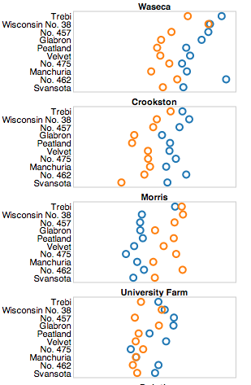

Barley

# Ruby-Band

[Alberto Arrigoni](https://github.com/arrigonialberto86/ruby-band)

Data mining and machine learning algorithms for Ruby

### Google Summer of Code 2013

installazione

```
gem install ruby-band
```

esempio

```
require 'ruby-band'

# Evaluator
eval = Weka::Attribute_selection::Evaluator::CfsSubsetEval.new

# Search algorithm
search = Weka::Attribute_selection::Search::GreedyStepwise.new

dataset = Core::Parser::parse_ARFF('weather.numeric.arff')
```

# Ruby-Band

Il **data mining** è l'insieme di tecniche e metodologie che hanno per oggetto l'estrazione di un sapere o di una conoscenza a partire da grandi quantità di dati (attraverso metodi automatici o semi-automatici) e l'utilizzo scientifico, industriale o operativo di questo sapere.

L'apprendimento automatico (noto in letteratura come **Machine Learning**) rappresenta una delle aree fondamentali dell'intelligenza artificiale e si occupa della realizzazione di sistemi e algoritmi che si basano su osservazioni come dati per la sintesi di nuova conoscenza. L'apprendimento può avvenire catturando caratteristiche di interesse provenienti da esempi, strutture dati o sensori, per analizzarle e valutarne le relazioni tra le variabili osservate.

# FFI

https://github.com/ffi/ffi

Ruby-FFI is a ruby extension for programmatically loading dynamic libraries, binding functions within them, and calling those functions from Ruby code. Moreover, a Ruby-FFI extension works without changes on Ruby and JRuby.

installazione

```
gem install ffi
```

esempio

```
require 'ffi'

module MyLib
  extend FFI::Library
  ffi_lib 'c'
  attach_function :puts, [ :string ], :int
end

MyLib.puts 'Hello, World using libc!'
```

# Chef

[figure not shown]

[opscode](http://www.opscode.com/chef/)

# Fonti

# Libri

- Learn to Program
- Everyday Scripting with Ruby: for Teams, Testers, and You
- Metaprogramming Ruby (la seconda edizione è in uscita)

# Links

- Ruby 2.0 API
- http://www.rubyinside.com/media/poignant-guide.pdf
- http://www.ruby-doc.org/docs/ProgrammingRuby/html/classes.html
- http://software-carpentry.org/v4/python/index.html
- https://www.ruby-lang.org/en/documentation/ruby-from-other-languages/to-ruby-from-java/
- https://www.ruby-lang.org/en/documentation/ruby-from-other-languages/

# Links

- [methods and blocks](http://blog.codahale.com/2005/11/24/a-ruby-howto-writing-a-method-that-uses-code-blocks/)
- [blocks](http://blog.mostof.it/why-ruby-part-two-blocks-and-closures/)
- [ruby singleton](http://www.devalot.com/articles/2008/09/ruby-singleton)
- [threading](http://blog.urbylog.info/2010/01/inside-ruby-19-interpreter-threading-in.html)
- [Parallel Programming with Celluloid](http://celluloid.io/)
- [Concurrency with JRuby](https://github.com/jruby/jruby/wiki/Concurrency-in-jruby)

# Forum

- [Ruby Forum](https://www.ruby-forum.com/)
- [mailing list EN](https://www.ruby-lang.org/en/community/mailing-lists/)
- [mailing list ITA](https://www.ruby-forum.com/forum/19)

# Siti

- [BioRuby](http://www.bioruby.org/)
- [BioGems](http://www.biogems.info/)
- [RVM](https://rvm.io/)

# Com'è stata creata la presentazione

- [Reveal.js](https://github.com/hakimel/reveal.js)
- [Pandoc](http://johnmacfarlane.net/pandoc/README.html)

# @INGM

# @INGM

### Istituto Nazionale di Genetica Molecolare

- 400 CPU-Cores
- 2 TB Ram
- 70 TB HD
- a lot of fun ^_^

Team:

- Ranzani Valeria, PhD Student
- Arrigoni Alberto, PhD Student

# Stage

# Tesi

# Venite a trovarci: via Franceso Sforza 35, Milano.